# mayarelmohr: Bey2ollak

Starting with exploring the data I had a question on mind, which was:

1- Do accidents tend to happen on rush hours?

Going through the steps, other questions revealed such as:

2- Is there a difference between the status of the road described by reporters and the status of the road described by bey2ollak?

3- Is there is any relationship between the peak of interaction and rush hours?

4- Is there a difference between weekends and weekdays for all reports?

5- Is there a difference between weekends and weekdays on rush hours?

Firstly I will begin with some basic data cleaning

```r
library("dplyr")
```

```r
library("ggplot2")
library("gridExtra")
bey2ollak = read.csv('../all-semi-unique.csv', encoding="UTF-8")
```

I removed data columns of insignificant values such as logos, background color,images, ads and values that are constant through the whole dataset

I also removed NAs from important columns such as rd.stid which indicates the road status id and the hours.

```r
filteredColumns = select(bey2ollak, - c(ad.aid, ad.bgcl, ad.bgcls, ad.fncl, ad.fncls, ad.lid ,ad.logo, ad.logo2x, ad.logoAndroidS , ad.logoAndroidH, ad.cm, ad.url, ad.g, rd.img, rd.cl, rd.rp.rpImg, rd.rp.img, rd.rp.type) )

filteredColumns = distinct(filteredColumns)

filteredColumns = filter(filteredColumns, !is.na(filteredColumns$rd.stid))

filteredColumns = filter(filteredColumns, !is.na(filteredColumns$rd.hr))
```

For the Date, I changed the date into a format that is clearer

```r
filteredColumns$crawl_date = strptime(as.character(filteredColumns$crawl_date),"%a %b %d %H:%M:%S UTC %Y")
filteredColumns$crawl_date = as.character(filteredColumns$crawl_date)
```

Let’s start by my first question:

1- Do accidents tend to happen on rush hours?

I’ll start my analysis on the comments reported by users

First of all, I’ll remove the duplicates from comments

```r
filteredColumns = filter(filteredColumns, !duplicated(filteredColumns$rd.rp.cmid))
```

Upon looking into data and the webpage for bey2ollak, the statuses for reports can be grouped into 10 categories

1- “7alawa” indicates that there is no traffic 2- “lazeez” lower level than the first one but still indicates that the road is going fine 3-“mashy” means that there is some kind of traffic but doesn’t cause the car to stop, this status is also exchanged by reports about km/hr. 4- “za7ma” it indicates that there is heavy traffic 5- “mafeesh amal” indicating that cars don’t move, very heavy traffic 6- “eh el nezam?” user are asking for updates 7- “Khatar” there is something dangerous about the road 8- “7adsa” an accident has happened that is causing the cars flow to stop 9- “3otl” indicating that there is a problem with the road 10- “other” indicates other causes.

```r
filteredColumns$rd.rp.cm[filteredColumns$rd.rp.stid == 1] = "7alawa"
filteredColumns$rd.rp.cm[filteredColumns$rd.rp.stid == 2] = "lazeez"
filteredColumns$rd.rp.cm[filteredColumns$rd.rp.stid == 3] = "mashy"
filteredColumns$rd.rp.cm[filteredColumns$rd.rp.stid == 4] = "za7ma"
filteredColumns$rd.rp.cm[filteredColumns$rd.rp.stid == 5] = "mafeesh amal"
filteredColumns$rd.rp.cm[filteredColumns$rd.rp.stid == 6] = "eh el nezam?"
filteredColumns$rd.rp.cm[filteredColumns$rd.rp.stid == 7] = "khatar"
filteredColumns$rd.rp.cm[filteredColumns$rd.rp.stid == 8] = "7adsa"
filteredColumns$rd.rp.cm[filteredColumns$rd.rp.stid == 9] = "3otl"
filteredColumns$rd.rp.cm[filteredColumns$rd.rp.stid == 10] = "other"
```

Assigning corresponding comments to NAs

```r
filteredColumns$rd.rp.cm[is.na(filteredColumns$rd.rp.stid == 1 )] = "7alawa"
filteredColumns$rd.rp.cm[is.na(filteredColumns$rd.rp.stid == 2 )] = "lazeez"
filteredColumns$rd.rp.cm[is.na(filteredColumns$rd.rp.stid == 3 )] = "mashy"
filteredColumns$rd.rp.cm[is.na(filteredColumns$rd.rp.stid == 4 )] = "za7ma"
filteredColumns$rd.rp.cm[is.na(filteredColumns$rd.rp.stid == 5 )] = "mafeesh amal"
filteredColumns$rd.rp.cm[is.na(filteredColumns$rd.rp.stid == 6 )] = "eh el nezam?"
filteredColumns$rd.rp.cm[is.na(filteredColumns$rd.rp.stid == 7 )] = "khatar"
filteredColumns$rd.rp.cm[is.na(filteredColumns$rd.rp.stid == 8 )] = "7adsa"
filteredColumns$rd.rp.cm[is.na(filteredColumns$rd.rp.stid == 9 )] = "3otl"
filteredColumns$rd.rp.cm[is.na(filteredColumns$rd.rp.stid == 10 )] = "other"
```

Now, let’s get the Actual Report Time from commenters and Actual read time from radar

```r
filteredColumns<- dplyr::mutate(filteredColumns, actual.rp.time = as.POSIXlt.character(filteredColumns$crawl_date) - 60*60*(filteredColumns$rd.rp.hr) - 60*(filteredColumns$rd.rp.mn) )

filteredColumns<- dplyr::mutate(filteredColumns, actual.rd.time = as.POSIXlt.character(filteredColumns$crawl_date) - 60*60*(filteredColumns$rd.hr) - 60*(filteredColumns$rd.mn) )
```

Secondly, let’s detect first when do rush hours happen

Assuming that we have 2 reported states for rush hours 1- “za7ma”" 2- “mafeesh amal” indicating that there is heavy traffic

Here I’m extracting the actual time in hours to start analysis

```r
filteredColumns = mutate(filteredColumns, rp.hours =(strftime(filteredColumns$actual.rp.time, format="%H" )))
filteredColumns = mutate(filteredColumns, rd.hours =(strftime(filteredColumns$actual.rd.time, format="%H" )))
```

Let’s see what are the rush hours

```r
za7ma = filter(filteredColumns, filteredColumns$rd.rp.stid == 4)
za7ma$hour <- as.numeric(za7ma$rp.hours)

mafeesh = filter(filteredColumns, filteredColumns$rd.rp.stid == 5)
mafeesh$hour <- as.numeric(mafeesh$rp.hours)
```

From the graph below, we can see that the frequency of both “mafeesh fayda” and “za7ma” The frequency from each from 14 to 18 which are 4 pm to 8 pm and at the morning, 8 and 9 pm Which makes sense such that these are times at which employees and students go back and from their jobs

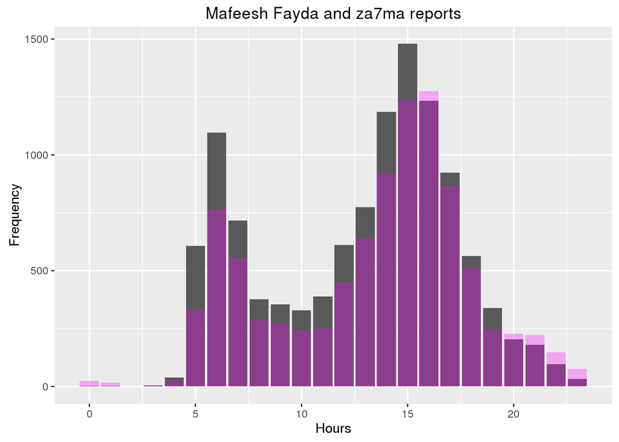

```r
ggplot() + geom_bar(data = za7ma, aes(x=hour)) + geom_bar(data = mafeesh, aes(x=hour), fill = 'magenta', alpha = '0.3') +ggtitle("Mafeesh Fayda and za7ma reports")+ xlab("Hours") + ylab("Frequency")
```

Let’s check when do accidents happen.. There is a great variation between the scale such that the samples size of accidents is very small compared to the rush hours

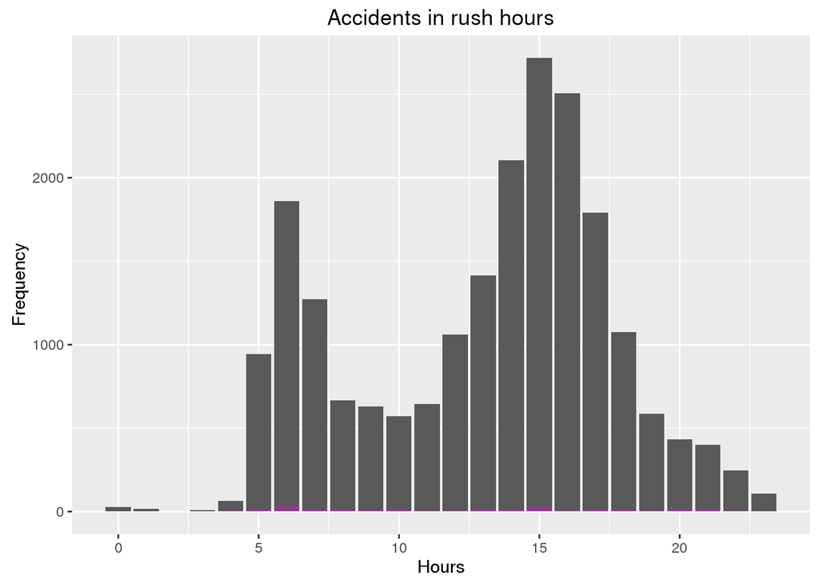

```r
accident = filter(filteredColumns, filteredColumns$rd.rp.stid == 8)
accident$hour = as.numeric(accident$rp.hours)

rushHoursRows = union (filter(filteredColumns, (filteredColumns$rd.rp.stid ==4)), filter(filteredColumns, (filteredColumns$rd.rp.stid ==5)))


p1 = ggplot() + geom_bar( data = rushHoursRows, aes(x=as.numeric(rp.hours))) + ggtitle("Rush hours")+ xlab("Hours") + ylab("Frequency")


p2= ggplot() + geom_bar(data = accident, aes(x = hour)) + ggtitle("Accidents ")+ xlab("Hours") + ylab("Frequency")



ggplot() + geom_bar( data = rushHoursRows, aes(x=as.numeric(rp.hours))) + geom_bar(data = accident, aes(x = hour), fill = "magenta", alpha ='0.3' ) + ggtitle("Accidents in rush hours")+ xlab("Hours") + ylab("Frequency")
```

Computing the mean value for times at which accidents occur

```r
mean(accident$hour)
```

```
## [1] 12.33333
```

```r
median(accident$hour)
```

```
## [1] 13
```

```r
sd(accident$hour)
```

```
## [1] 5.653309
```

Computing the mean Value for rush hours

```r
mean(za7ma$hour)
```

```
## [1] 12.78397
```

```r
median(za7ma$hour)
```

```
## [1] 14
```

```r
sd(za7ma$hour)
```

```
## [1] 4.503905
```

```r
mean(mafeesh$hour)
```

```
## [1] 13.39218
```

```r
median(mafeesh$hour)
```

```
## [1] 15
```

```r
sd(mafeesh$hour)
```

```
## [1] 4.560518
```

The three plots here show a relatively close median

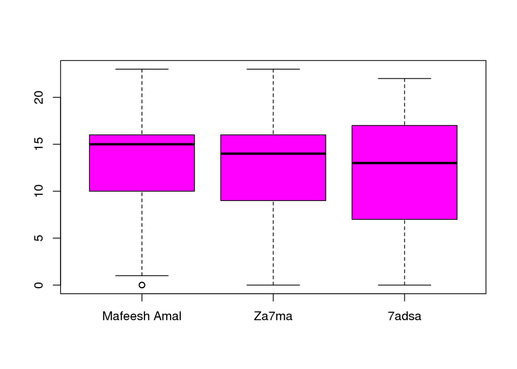

```r
boxplot(mafeesh$hour, za7ma$hour, accident$hour, names=c("Mafeesh Amal", "Za7ma", "7adsa"), col="magenta")
```

```r
t.test(accident$hour, za7ma$hour)
```

```
##
##  Welch Two Sample t-test
##
## data:  accident$hour and za7ma$hour
## t = -1.293, df = 273.87, p-value = 0.1971
## alternative hypothesis: true difference in means is not equal to 0
## 95 percent confidence interval:
##  -1.1367305  0.2354596
## sample estimates:
## mean of x mean of y
##  12.33333  12.78397
```

Another question is whether there is a difference between the status of the road described by reporters and the status of the road described by bey2ollak

Let’s try to examine each situation

For status id = 1 meaning “7alawa”

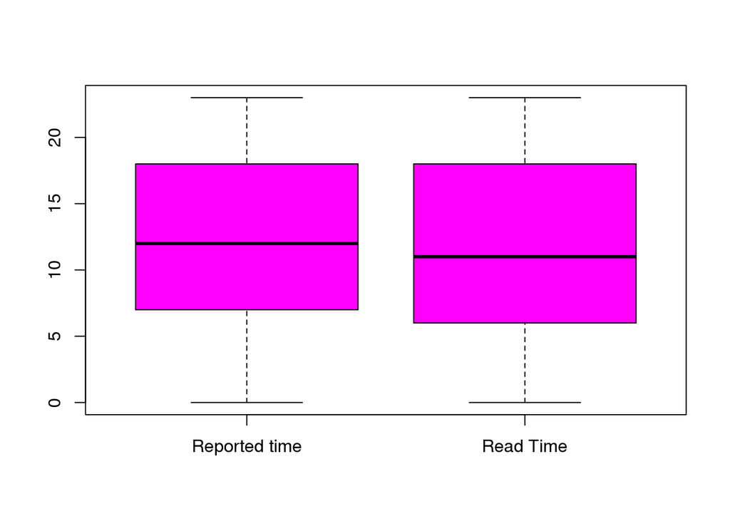

```r
halawa.rp = filter(filteredColumns, filteredColumns$rd.rp.stid == 1)
halawa.rp$hour =  as.numeric(halawa.rp$rp.hours)
halawa.rd = filter(filteredColumns, filteredColumns$rd.stid == 1)
halawa.rd$hour =  as.numeric(halawa.rd$rd.hours)

p11 = ggplot() + geom_bar(data = halawa.rp, aes(x=hour)) + geom_bar(data = halawa.rd, aes(x=hour), fill = 'magenta', alpha = '0.4') + ggtitle("Halawa rp Vs rd")

p12 = boxplot(halawa.rp$hour, halawa.rd$hour, names = c("Reported time", "Read Time") ,col="Magenta")
```

For status id = 2 meaning “lazeez”

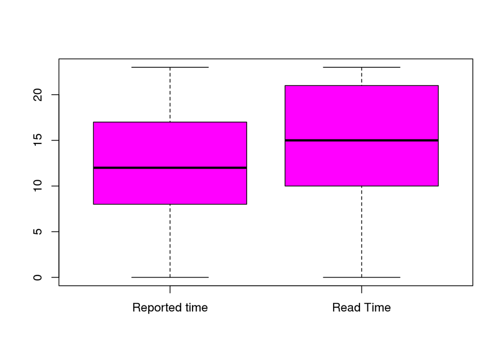

```r
lazeez.rp = filter(filteredColumns, filteredColumns$rd.rp.stid == 2)
lazeez.rp$hour = as.numeric(lazeez.rp$rp.hours)
lazeez.rd = filter(filteredColumns, filteredColumns$rd.stid == 2)
lazeez.rd$hour = as.numeric(lazeez.rd$rd.hours)

p21 = ggplot() + geom_bar(data = lazeez.rp, aes(x=hour)) + geom_bar(data = lazeez.rd, aes(x=hour), fill = 'magenta', alpha = '0.4') + ggtitle("Lazeez rp Vs rd")

boxplot(lazeez.rp$hour, lazeez.rd$hour, names = c("Reported time", "Read Time") ,col="Magenta")
```

For status id = 3 meaning “mashy”

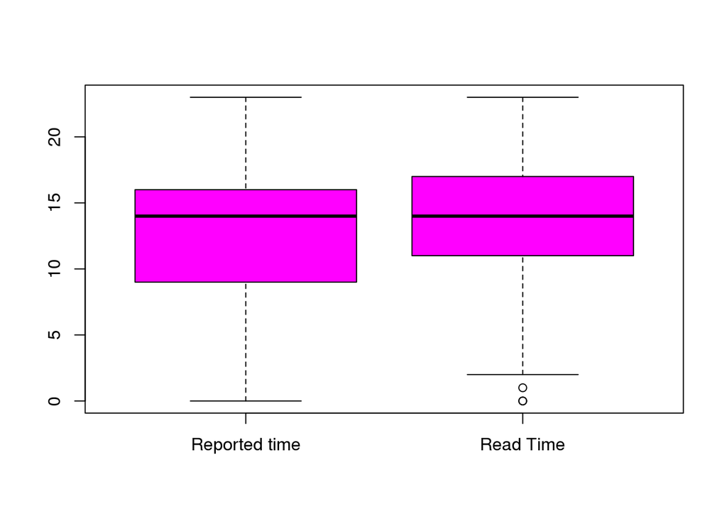

```r
mashy.rp = filter(filteredColumns, filteredColumns$rd.rp.stid == 3)
mashy.rp$hour = as.numeric(mashy.rp$rp.hours)
mashy.rd = filter(filteredColumns, filteredColumns$rd.stid == 3)
mashy.rd$hour = as.numeric(mashy.rd$rd.hours)

p31 = ggplot() + geom_bar(data = mashy.rp, aes(x=hour)) + geom_bar(data = mashy.rd, aes(x=hour), fill = 'magenta', alpha = '0.4') + ggtitle("Lazeez rp Vs rd")

boxplot(mashy.rp$hour, mashy.rd$hour, names = c("Reported time", "Read Time") ,col="Magenta")
```

For status id = 4 meaning “za7ma”

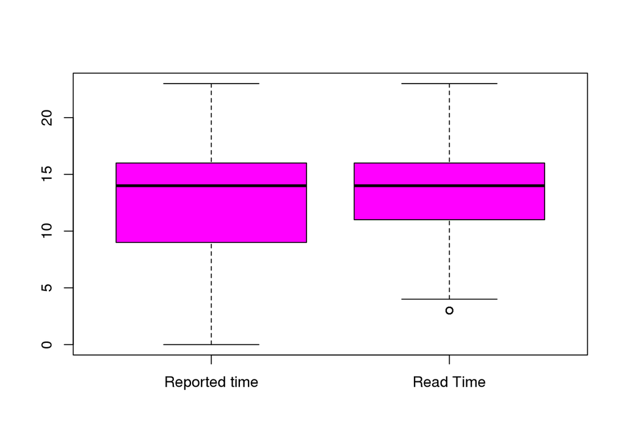

```r
za7ma.rp = filter(filteredColumns, filteredColumns$rd.rp.stid == 4)
za7ma.rp$hour = as.numeric(za7ma.rp$rp.hours)
za7ma.rd = filter(filteredColumns, filteredColumns$rd.stid == 4)
za7ma.rd$hour = as.numeric(za7ma.rd$rd.hours)

p41 = ggplot() + geom_bar(data = za7ma.rp, aes(x=hour)) + geom_bar(data = za7ma.rd, aes(x=hour), fill = 'magenta', alpha = '0.4') + ggtitle("za7ma rp Vs rd")

boxplot(za7ma.rp$hour, za7ma.rd$hour, names = c("Reported time", "Read Time") ,col="Magenta")
```

For status id = 5 meaning “mafeesh amal”

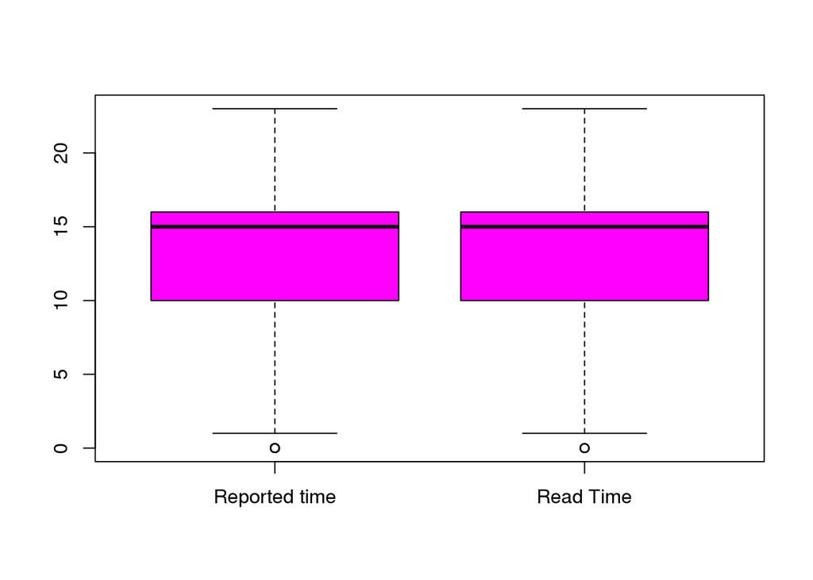

```r
mafeesh.amal.rp = filter(filteredColumns, filteredColumns$rd.rp.stid == 5)
mafeesh.amal.rp$hour = as.numeric(mafeesh.amal.rp$rp.hours)
mafeesh.amal.rd = filter(filteredColumns, filteredColumns$rd.stid == 5)
mafeesh.amal.rd$hour = as.numeric(mafeesh.amal.rd$rd.hours)

p51 = ggplot() + geom_bar(data = mafeesh.amal.rp, aes(x=hour)) + geom_bar(data = mafeesh.amal.rd, aes(x=hour), fill = 'magenta', alpha = '0.4') + ggtitle("Lazeez rp Vs rd")

boxplot(mafeesh.amal.rp$hour, mafeesh.amal.rd$hour, names = c("Reported time", "Read Time") ,col="Magenta")
```

For status id = 6 meaning “eh el nezam”

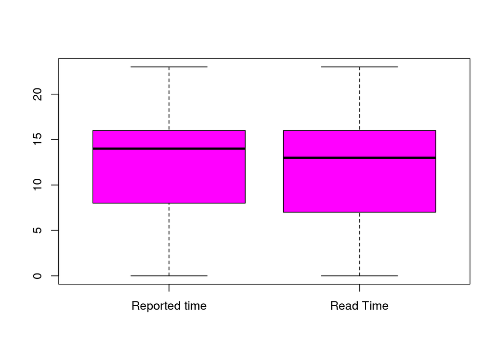

```r
eh.nezam.rp = filter(filteredColumns, filteredColumns$rd.rp.stid == 6)
eh.nezam.rp$hour = as.numeric(eh.nezam.rp$rp.hours)
eh.nezam.rd = filter(filteredColumns, filteredColumns$rd.stid == 6)
eh.nezam.rd$hour = as.numeric(eh.nezam.rd$rd.hours)

p61 = ggplot() + geom_bar(data = eh.nezam.rp, aes(x=hour)) + geom_bar(data = eh.nezam.rd, aes(x=hour), fill = 'magenta', alpha = '0.4') + ggtitle("Eh el nezam rp Vs rd")

boxplot(eh.nezam.rp$hour, eh.nezam.rd$hour, names = c("Reported time", "Read Time") ,col="Magenta")
```

For status id = 7 meaning “khatar”

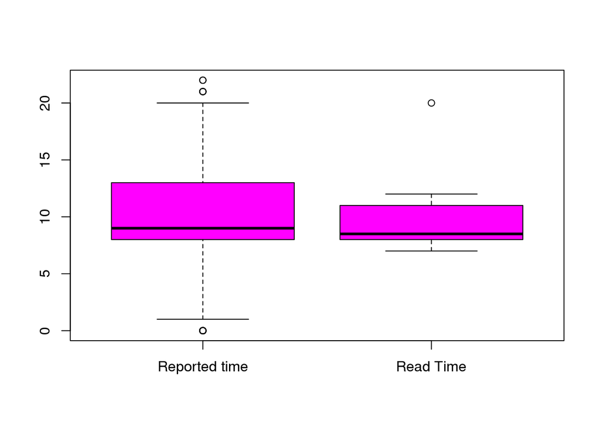

```r
khatar.rp = filter(filteredColumns, filteredColumns$rd.rp.stid == 7)
khatar.rp$hour = as.numeric(khatar.rp$rp.hours)
khatar.rd = filter(filteredColumns, filteredColumns$rd.stid == 7)
khatar.rd$hour = as.numeric(khatar.rd$rd.hours)

p71 = ggplot() + geom_bar(data = khatar.rp, aes(x=hour)) + geom_bar(data = khatar.rd, aes(x=hour), fill = 'magenta', alpha = '0.4') + ggtitle("Khatar rp Vs rd")

boxplot(khatar.rp$hour, khatar.rd$hour, names = c("Reported time", "Read Time") ,col="Magenta")
```

For status id = 8 meaning “7adsa”

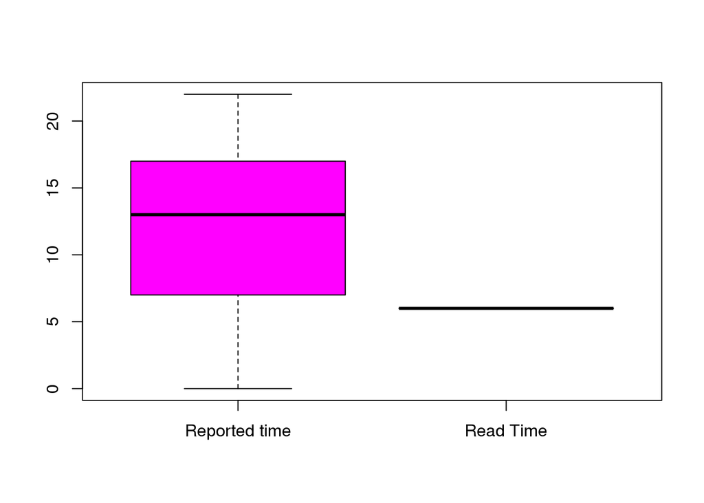

```r
accident.rp = filter(filteredColumns, filteredColumns$rd.rp.stid == 8)
accident.rp$hour <- as.numeric(accident.rp$rp.hours)
accident.rd = filter(filteredColumns, filteredColumns$rd.stid == 8)
accident.rd$hour <- as.numeric(accident.rd$rd.hours)

p81 = ggplot() + geom_bar(data = accident.rp, aes(x=hour)) + geom_bar(data = accident.rd, aes(x=hour), fill = 'magenta', alpha = '0.4') + ggtitle("Accident rp Vs rd")

boxplot(accident.rp$hour, accident.rd$hour, names = c("Reported time", "Read Time") ,col="Magenta")
```

For status id = 9 meaning “3otl”

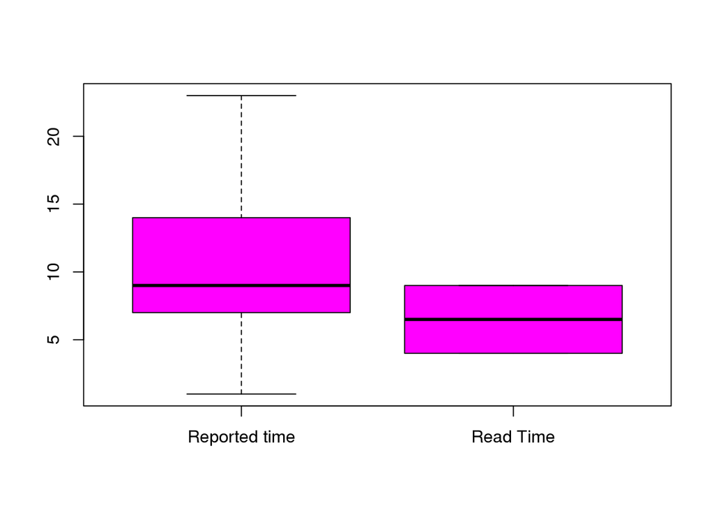

```r
damage.rp = filter(filteredColumns, filteredColumns$rd.rp.stid == 9)
damage.rp$hour <- as.numeric(damage.rp$rp.hours)
damage.rd = filter(filteredColumns, filteredColumns$rd.stid == 9)
damage.rd$hour <- as.numeric(damage.rd$rd.hours)

p91 = ggplot() + geom_bar(data = damage.rp, aes(x=hour)) + geom_bar(data = damage.rd, aes(x=hour), fill = 'magenta', alpha = '0.4') + ggtitle("3otl rp Vs rd")

boxplot(damage.rp$hour, damage.rd$hour, names = c("Reported time", "Read Time") ,col="Magenta")
```

For status id = 10 meaning “other”

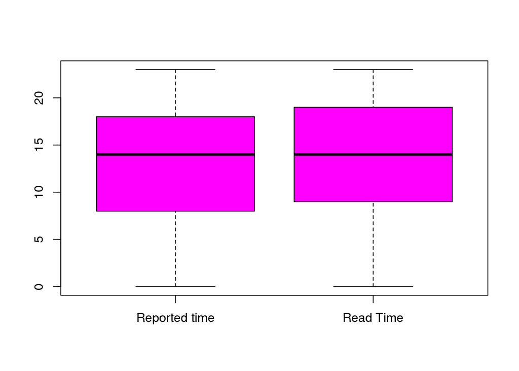

```r
other.rp = filter(filteredColumns, filteredColumns$rd.rp.stid == 10)
other.rp$hour <- as.numeric(other.rp$rp.hours)
other.rd = filter(filteredColumns, filteredColumns$rd.stid == 10)
other.rd$hour <- as.numeric(other.rd$rd.hours)

p101 = ggplot() + geom_bar(data = other.rp, aes(x=hour)) + geom_bar(data = other.rd, aes(x=hour), fill = 'magenta', alpha = '0.4') + ggtitle("Others rp Vs rd")

boxplot(other.rp$hour, other.rd$hour, names = c("Reported time", "Read Time") ,col="Magenta")
```

For all plots

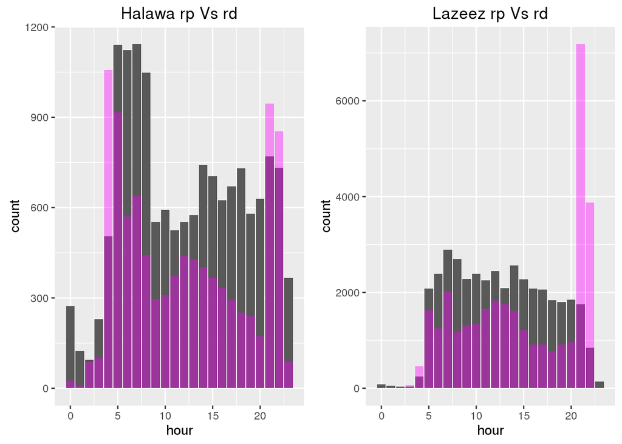

```r
grid.arrange(p11,p21, ncol=2)
```

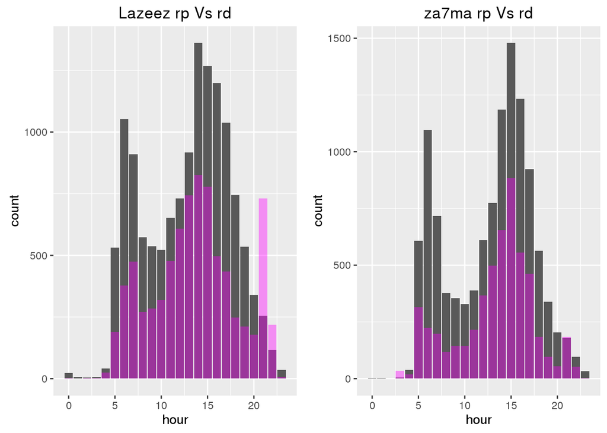

```r
grid.arrange(p31,p41, ncol=2)
```

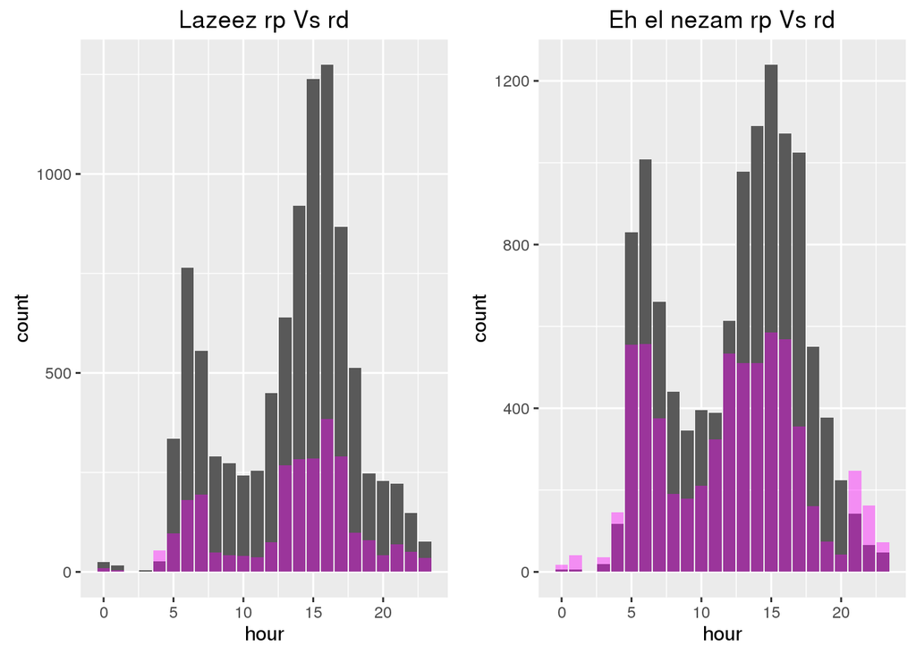

```r
grid.arrange(p51,p61, ncol=2)
```

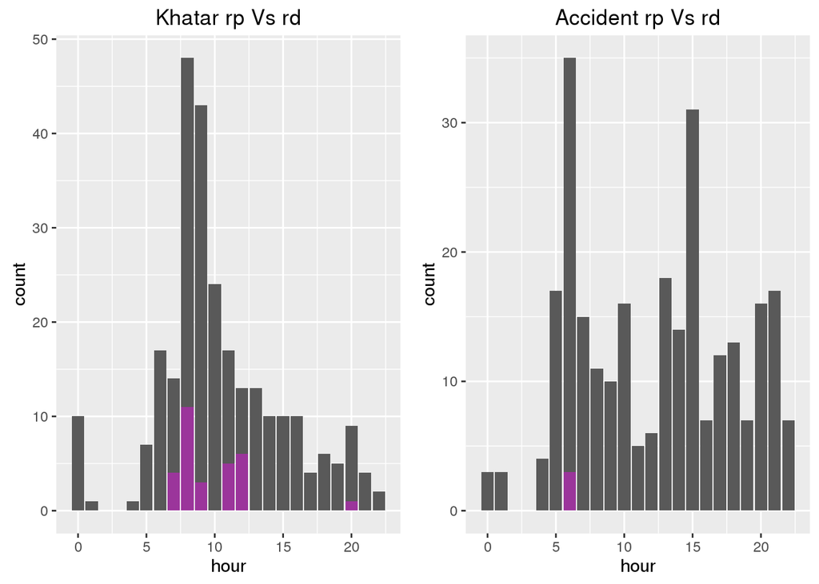

```r
grid.arrange(p71,p81, ncol=2)
```

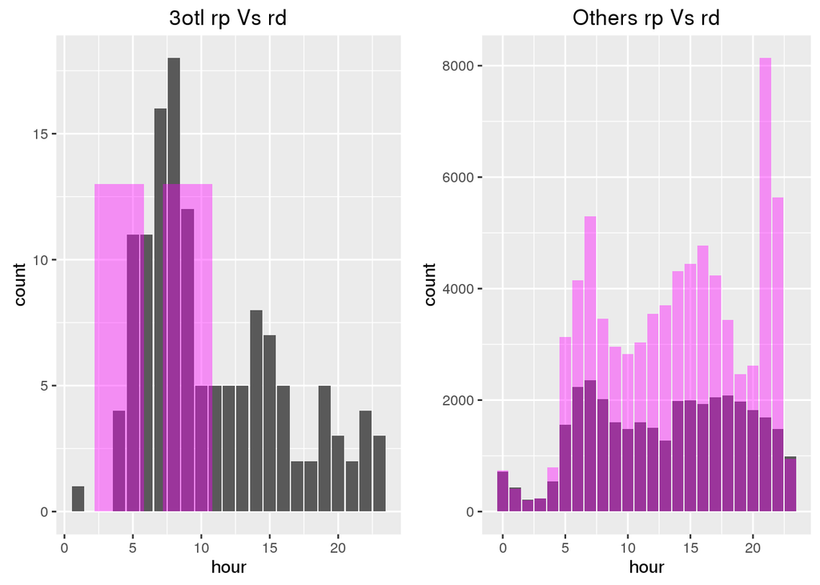

```r
grid.arrange(p91,p101, ncol=2)
```

Here, you can find the difference between the two reports, using central limit theory

```r
means.rp  = c(mean(halawa.rp$hour), mean(lazeez.rp$hour), mean(mashy.rp$hour), mean(za7ma.rp$hour), mean(mafeesh.amal.rp$hour), mean(eh.nezam.rp$hour), mean(khatar.rp$hour), mean(accident.rp$hour), mean(damage.rp$hour), mean(other.rp$hour) )

means.rp
```

```
##  [1] 12.14010 12.63490 12.84251 12.78397 13.39218 12.52509 10.41791
##  [8] 12.33333 10.84328 12.99225
```

```r
means.rd =  c(mean(halawa.rd$hour), mean(lazeez.rd$hour), mean(mashy.rd$hour), mean(za7ma.rd$hour), mean(mafeesh.amal.rd$hour), mean(eh.nezam.rd$hour), mean(khatar.rd$hour), mean(accident.rd$hour), mean(damage.rd$hour), mean(other.rd$hour) )

means.rd
```

```
##  [1] 12.041909 14.819625 13.619042 13.293693 13.471691 12.077578  9.666667
##  [8]  6.000000  6.500000 13.806035
```

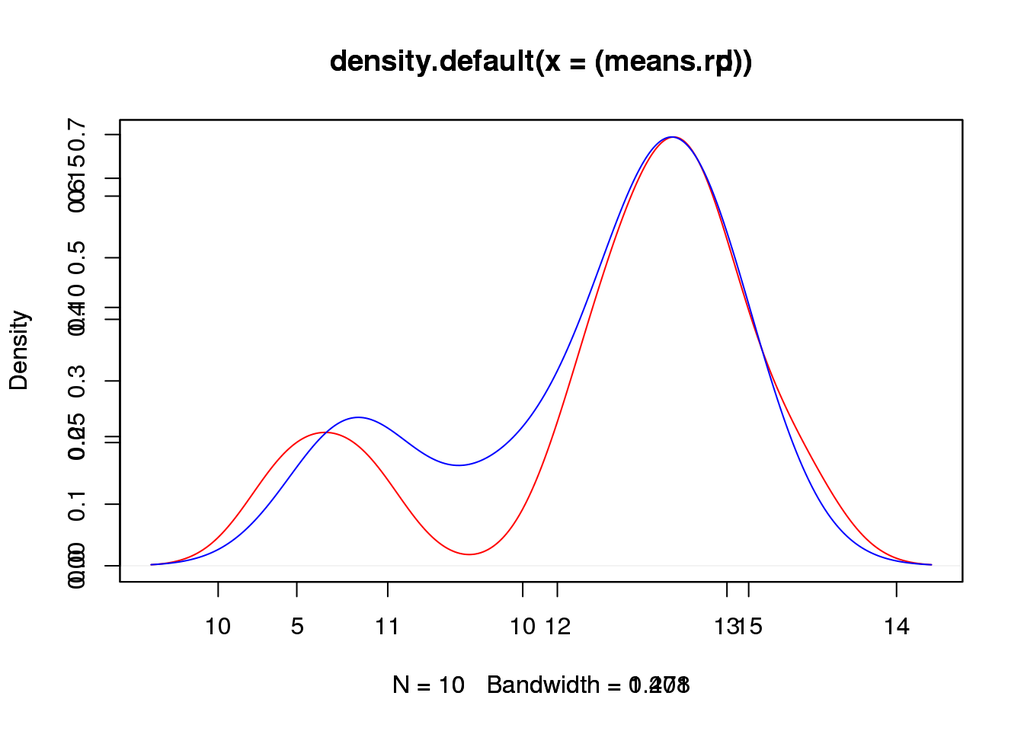

```r
plot(density((means.rp)), type= "l", col = "red")
par(new=TRUE)
plot(density((means.rd)), type= "l", col = "blue")
```

Applying t-test on both the mean of reported values and mean of read values

```r
t.test(means.rd,means.rp)
```

```
##
##  Welch Two Sample t-test
##
## data:  means.rd and means.rp
## t = -0.73979, df = 10.649, p-value = 0.4754
## alternative hypothesis: true difference in means is not equal to 0
## 95 percent confidence interval:
##  -3.033932  1.512074
## sample estimates:
## mean of x mean of y
##  11.52962  12.29055
```

The value is t = -0.74 with 95 percent confidence and a very high p-value meaning that two means are approximately equal

Another Question could be is if there is any relationship between the peak of interaction and rush hours ie If the number of reports has something to do with rush hours

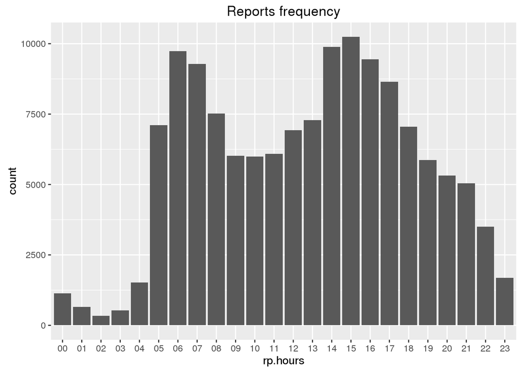

```r
filteredColumns = filter(filteredColumns, !is.na(filteredColumns$rd.rp.stid))
ggplot(data = filteredColumns, aes(x = rp.hours)) + geom_bar() + ggtitle("Reports frequency")
```

Comparing the total number of reports with the rush hours that we have inferred before from combining reported statuses as “za7ma” and “mafeesh amal”

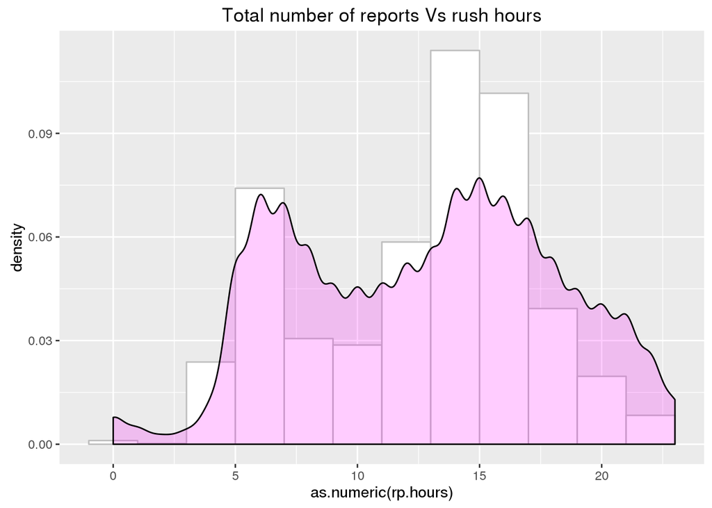

```r
ggplot() + geom_histogram(data = rushHoursRows,aes(x=as.numeric(rp.hours), y=..density..), colour = "gray", fill = "white", binwidth = 2)  + geom_density(data = filteredColumns, aes(x = as.numeric(rp.hours)), alpha = .2, fill = "magenta") + ggtitle("Total number of reports Vs rush hours")
```

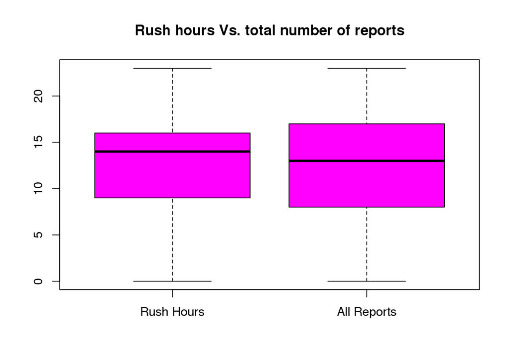

```r
boxplot(as.numeric(rushHoursRows$rp.hours), as.numeric(filteredColumns$rp.hours), main = "Rush hours Vs. total number of reports",names = c("Rush Hours", "All Reports") ,col="Magenta")
```

```r
t.test(as.numeric(rushHoursRows$rp.hours),as.numeric(filteredColumns$rp.hours))
```

```
##
##  Welch Two Sample t-test
##
## data:  as.numeric(rushHoursRows$rp.hours) and as.numeric(filteredColumns$rp.hours)
## t = 9.2131, df = 30752, p-value < 2.2e-16
## alternative hypothesis: true difference in means is not equal to 0
## 95 percent confidence interval:
##  0.2490184 0.3836059
## sample estimates:
## mean of x mean of y
##  13.06037  12.74406
```

Another question is whether

there is a difference between weekends and weekdays for all reports

```r
filteredColumns <- mutate(filteredColumns, rd.days = (strftime(filteredColumns$crawl_date, format="%a" )))
```

Here I choose days that are Saturdays or Fridays for weekends

```r
weekend = union(filter(filteredColumns,(filteredColumns$rd.days ==  "Fri")), filter(filteredColumns,(filteredColumns$rd.days ==  "Sat")))
weekdays = setdiff(filteredColumns, weekend)
```

The graph here presents the number of reports on Weekends Vs the reports on normal working days

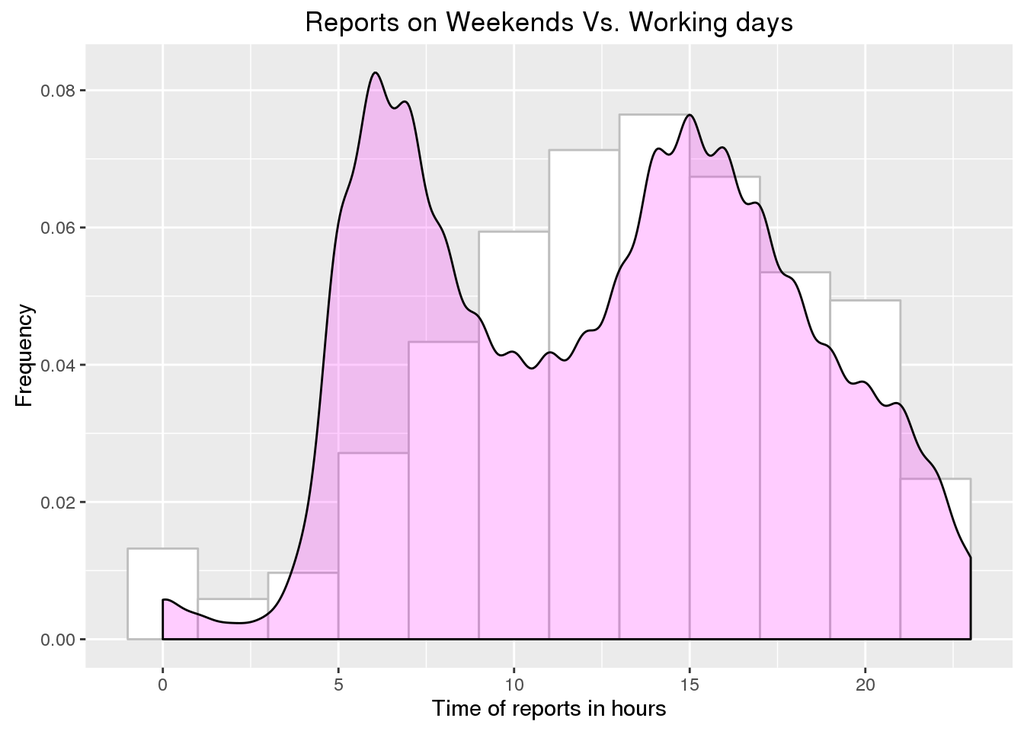

```r
ggplot() + geom_histogram(data = weekend,aes(x=as.numeric(rp.hours), y=..density..), colour = "gray", fill = "white", binwidth = 2)  + geom_density(data = weekdays, aes(x = as.numeric(rp.hours)), alpha = .2, fill = "magenta") + ggtitle("Reports on Weekends Vs. Working days")+ xlab("Time of reports in hours") + ylab("Frequency")
```

Check the t-test value

```r
t.test(as.numeric(weekend$rp.hours), as.numeric(weekdays$rp.hours))
```

```
##
##  Welch Two Sample t-test
##
## data:  as.numeric(weekend$rp.hours) and as.numeric(weekdays$rp.hours)
## t = 34.761, df = 42088, p-value < 2.2e-16
## alternative hypothesis: true difference in means is not equal to 0
## 95 percent confidence interval:
##  1.150792 1.288324
## sample estimates:
## mean of x mean of y
##  13.72416  12.50460
```

For rushhours, we can do the following

```r
za7ma.weekend = union(filter(weekend, (weekend$rd.stid ==  4)), filter(weekend, weekend$rd.stid == 5))
za7ma.weekdays = union(filter(weekdays, (weekdays$rd.stid ==  4 )), filter(weekdays, weekdays$rd.stid == 5))
```

Here the result is distribution significant given that on weekends the rush hours at morning, starting from 8 am disappear which happens since people don’t normally go to their jobs on weekends, so the rush hours change on weekends from normal weekdays

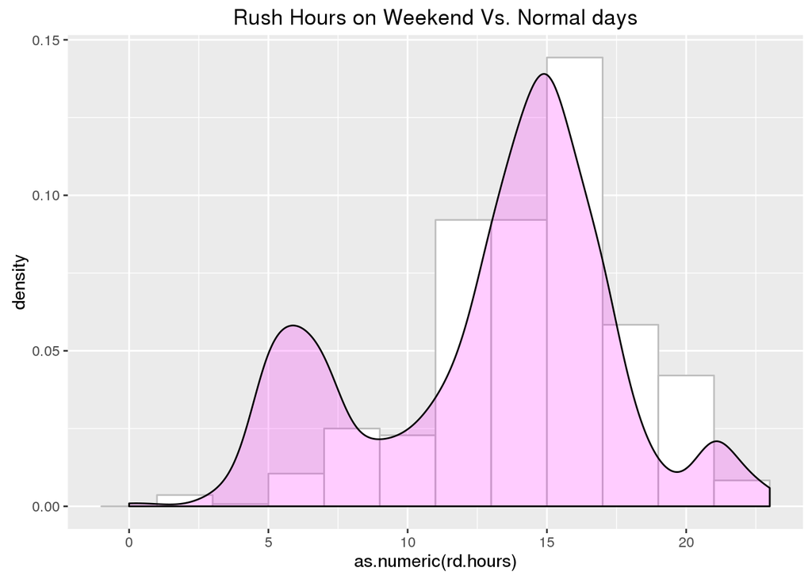

```r
ggplot() + geom_histogram(data = za7ma.weekend,aes(x=as.numeric(rd.hours), y=..density..), colour = "gray", fill = "white", binwidth = 2)  + geom_density(data = za7ma.weekdays, aes(x = as.numeric(rd.hours)), alpha = .2, fill = "magenta") + ggtitle("Rush Hours on Weekend Vs. Normal days")
```

```r
t.test(as.numeric(za7ma.weekend$rd.hours), as.numeric(za7ma.weekdays$rd.hours))
```

```
##
##  Welch Two Sample t-test
##
## data:  as.numeric(za7ma.weekend$rd.hours) and as.numeric(za7ma.weekdays$rd.hours)
## t = 19.028, df = 2368.6, p-value < 2.2e-16
## alternative hypothesis: true difference in means is not equal to 0
## 95 percent confidence interval:
##  1.864595 2.293078
## sample estimates:
## mean of x mean of y
##  15.10515  13.02631
```